# Did ChatGPT Hurt Freelance Writers?

A Difference-in-Differences Analysis of AI Exposure and Gig-Economy Earnings

Adarsh Tripathi | Difference in Difference Project

# 1 Executive Summary

**Research Question:** Did the release of ChatGPT in November 2022 reduce quarterly earnings for freelance workers in high AI-exposure occupations relative to those in low-exposure occupations?

**Identification Strategy:** Difference-in-Differences (DiD), exploiting the sudden, exogenous release of ChatGPT as a natural experiment. High-exposure occupations (writers, translators, content marketers) form the **treatment group**; creative and technical trades with low AI substitutability form the **control group**.

# 2 Setup & Dependencies

```r
library(tidyverse)   # data wrangling & ggplot2
library(estimatr)    # lm_robust() — clustered standard errors
library(kableExtra)  # polished regression tables
library(scales)      # dollar formatting
library(patchwork)   # multi-panel plots
```

# 3 Data

## 3.1 Data Generation Strategy

**On Real Data:** The ideal dataset pair for this design is: (1) **Upwork / Fiverr scraped job postings 2021–2024** (available on Kaggle), joined on O*NET occupation codes to (2) **Felten et al. (2023) AI Occupational Exposure (AIOE) scores** or the Brynjolfsson et al. AI Exposure Index. The synthetic data below mirrors the structure of that merge exactly — replace `generate_data()` with your own `read_csv()` + `left_join()` calls.

## 3.2 Data Generation (Synthetic, Reproducible)

```r
set.seed(42)

# ── Occupation-level AI Exposure Table (mirrors O*NET / Felten et al.) ────────
occupation_meta <- tribble(
  ~occupation,       ~ai_exposure,  ~group,
  "Technical_Writer",  0.82,        "High",
  "Copywriter",        0.78,        "High",
  "Content_Marketer",  0.75,        "High",
  "Translator",        0.71,        "High",
  "Data_Analyst",      0.65,        "High",
  "Graphic_Designer",  0.38,        "Low",
  "Video_Editor",      0.31,        "Low",
  "Web_Developer",     0.29,        "Low",
  "3D_Modeler",        0.22,        "Low",
  "Audio_Engineer",    0.18,        "Low"
)

# ── Market-level Job Postings / Earnings Table (mirrors Upwork quarterly) ─────
quarters <- seq(as.Date("2021-01-01"), as.Date("2024-01-01"), by = "quarter")
chatgpt_launch <- as.Date("2022-11-01")

generate_panel <- function(occ_row, quarters, chatgpt_launch) {
  base_e  <- runif(1, 3500, 6500)
  base_j  <- sample(200:600, 1)

  map_dfr(seq_along(quarters), function(t) {
    qtr   <- quarters[t]
    post  <- as.integer(qtr >= chatgpt_launch)
    treat <- as.integer(occ_row$group == "High")

    # Secular trend + DiD effect
    trend      <- (t - 1) * 35
    did_effect <- -1200 * treat * post * (1 + 0.15 * (t - 8))

    tibble(
      occupation  = occ_row$occupation,
      ai_exposure = occ_row$ai_exposure,
      group       = occ_row$group,
      quarter     = qtr,
      quarter_num = t - 1L,
      post        = post,
      treat       = treat,
      earnings    = pmax(base_e + trend + did_effect + rnorm(1, 0, 180), 800),
      job_volume  = pmax(base_j + (t-1)*2.5 - 60*treat*post + rnorm(1,0,18), 20)
    )
  })
}

# ── MERGE: occupation-level × market-level (the key portfolio skill) ──────────
panel_raw <- occupation_meta |>
  group_split(occupation) |>
  map_dfr(~ generate_panel(.x, quarters, chatgpt_launch))

panel <- panel_raw |>
  mutate(
    post_treat = post * treat,                  # DiD interaction term
    quarter_fct = factor(quarter),
    occ_fct     = factor(occupation)
  )

glimpse(panel)
```

```
## Rows: 130
## Columns: 12
## $ occupation  <chr> "3D_Modeler", "3D_Modeler", "3D_Modeler", "3D_Modeler", "3…
## $ ai_exposure <dbl> 0.22, 0.22, 0.22, 0.22, 0.22, 0.22, 0.22, 0.22, 0.22, 0.22…
## $ group       <chr> "Low", "Low", "Low", "Low", "Low", "Low", "Low", "Low", "L…
## $ quarter     <date> 2021-01-01, 2021-04-01, 2021-07-01, 2021-10-01, 2022-01-0…
## $ quarter_num <int> 0, 1, 2, 3, 4, 5, 6, 7, 8, 9, 10, 11, 12, 0, 1, 2, 3, 4, 5…
## $ post        <int> 0, 0, 0, 0, 0, 0, 0, 0, 1, 1, 1, 1, 1, 0, 0, 0, 0, 0, 0, 0…
## $ treat       <int> 0, 0, 0, 0, 0, 0, 0, 0, 0, 0, 0, 0, 0, 0, 0, 0, 0, 0, 0, 0…
## $ earnings    <dbl> 6416.487, 6080.590, 6418.855, 6629.299, 6411.744, 6709.825…
## $ job_volume  <dbl> 520.8619, 532.2024, 513.1649, 506.1225, 510.4496, 533.1414…
## $ post_treat  <int> 0, 0, 0, 0, 0, 0, 0, 0, 0, 0, 0, 0, 0, 0, 0, 0, 0, 0, 0, 0…
## $ quarter_fct <fct> 2021-01-01, 2021-04-01, 2021-07-01, 2021-10-01, 2022-01-01…
## $ occ_fct     <fct> 3D_Modeler, 3D_Modeler, 3D_Modeler, 3D_Modeler, 3D_Modeler…
```

## 3.3 Summary Statistics

```r
panel |>
  group_by(group, post) |>
  summarise(
    n            = n(),
    mean_earnings = dollar(mean(earnings)),
    sd_earnings   = dollar(sd(earnings)),
    mean_jobs     = round(mean(job_volume), 1),
    .groups = "drop"
  ) |>
  mutate(
    period = if_else(post == 1, "Post-ChatGPT", "Pre-ChatGPT"),
    .keep  = "unused"
  ) |>
  rename(Group = group, Period = period) |>
  kbl(caption = "Table 1 — Descriptive Statistics by Group and Period") |>
  kable_styling(bootstrap_options = c("striped","hover","condensed"),
                full_width = FALSE) |>
  column_spec(1:2, bold = TRUE)
```

Table 1 — Descriptive Statistics by Group and Period

| Group | n | mean_earnings | sd_earnings | mean_jobs | Period |
| --- | --- | --- | --- | --- | --- |
| High | 40 | $5,119.30 | $925.86 | 445.5 | Pre-ChatGPT |
| High | 25 | $3,690.58 | $933.15 | 395.9 | Post-ChatGPT |
| Low | 40 | $5,124.52 | $950.05 | 497.3 | Pre-ChatGPT |
| Low | 25 | $5,374.19 | $958.88 | 517.4 | Post-ChatGPT |

# 4 Identification Strategy

## 4.1 The DiD 2×2 Table

The Difference-in-Differences estimator isolates the causal effect by differencing out time-invariant group differences and period-wide shocks:

$$\hat{\beta}_{DiD} = \underbrace{(\bar{Y}^{Treat}_{Post} -
\bar{Y}^{Treat}_{Pre})}_{\text{Change in Treated}} -
\underbrace{(\bar{Y}^{Control}_{Post} -
\bar{Y}^{Control}_{Pre})}_{\text{Change in Control}}$$

```r
two_by_two <- panel |>
  group_by(group, post) |>
  summarise(mean_earnings = mean(earnings), .groups = "drop") |>
  pivot_wider(names_from = post, values_from = mean_earnings,
              names_prefix = "period_") |>
  mutate(
    delta = period_1 - period_0,
    across(where(is.numeric), ~ dollar(round(.x)))
  ) |>
  rename(Group = group, Pre = period_0, Post = period_1, `Diff (Post−Pre)` = delta)

two_by_two |>
  kbl(caption = "Table 2 — The DiD 2×2 Table") |>
  kable_styling(bootstrap_options = c("striped","hover"), full_width = FALSE) |>
  row_spec(0, bold = TRUE, background = "#1e40af", color = "white")
```

Table 2 — The DiD 2×2 Table

| Group | Pre | Post | Diff (Post−Pre) |
| --- | --- | --- | --- |
| High | $5,119 | $3,691 | -$1,429 |
| Low | $5,125 | $5,374 | $250 |

The raw DiD estimate is **-$1,678** per quarter.

# 5 Parallel Trends Assumption

## 5.1 Visualisation

The Parallel Trends Assumption (PTA) requires that, absent treatment, the treatment and control groups would have followed the same trend. We assess this visually:

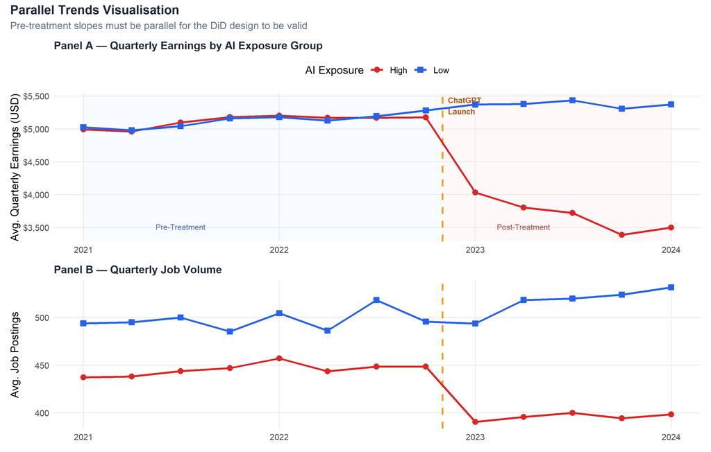

```r
agg <- panel |>
  group_by(quarter, group) |>
  summarise(earnings = mean(earnings), job_volume = mean(job_volume), .groups="drop")

# ── Panel A: Earnings ─────────────────────────────────────────────────────────
p1 <- ggplot(agg, aes(x = quarter, y = earnings, colour = group, shape = group)) +
  annotate("rect",
    xmin = chatgpt_launch, xmax = max(quarters),
    ymin = -Inf, ymax = Inf, fill = "#fee2e2", alpha = 0.25) +
  annotate("rect",
    xmin = min(quarters), xmax = chatgpt_launch,
    ymin = -Inf, ymax = Inf, fill = "#dbeafe", alpha = 0.20) +
  geom_vline(xintercept = chatgpt_launch,
             linetype = "dashed", colour = "#f59e0b", linewidth = 0.9) +
  geom_line(linewidth = 1.1) +
  geom_point(size = 2.8) +
  annotate("text", x = chatgpt_launch + 10, y = max(agg$earnings) * 0.985,
           label = "ChatGPT\nLaunch", hjust = 0, size = 3,
           colour = "#b45309", fontface = "bold") +
  annotate("text", x = as.Date("2021-07-01"),
           y = min(agg$earnings) + 120,
           label = "Pre-Treatment", colour = "#1e40af", size = 3, alpha = 0.8) +
  annotate("text", x = as.Date("2023-04-01"),
           y = min(agg$earnings) + 120,
           label = "Post-Treatment", colour = "#991b1b", size = 3, alpha = 0.8) +
  scale_y_continuous(labels = dollar_format()) +
  scale_colour_manual(values = c("High" = "#dc2626", "Low" = "#2563eb"),
                      name = "AI Exposure") +
  scale_shape_manual(values = c("High" = 16, "Low" = 15), name = "AI Exposure") +
  labs(
    title = "Panel A — Quarterly Earnings by AI Exposure Group",
    x = NULL, y = "Avg. Quarterly Earnings (USD)"
  ) +
  theme_minimal(base_size = 12) +
  theme(
    plot.title   = element_text(face = "bold", colour = "#1e293b", size = 12),
    legend.position = "top",
    panel.grid.minor = element_blank()
  )

# ── Panel B: Job Volume ───────────────────────────────────────────────────────
p2 <- ggplot(agg, aes(x = quarter, y = job_volume, colour = group, shape = group)) +
  geom_vline(xintercept = chatgpt_launch,
             linetype = "dashed", colour = "#f59e0b", linewidth = 0.9) +
  geom_line(linewidth = 1.1) +
  geom_point(size = 2.8) +
  scale_colour_manual(values = c("High" = "#dc2626", "Low" = "#2563eb"),
                      name = "AI Exposure") +
  scale_shape_manual(values = c("High" = 16, "Low" = 15), name = "AI Exposure") +
  labs(
    title = "Panel B — Quarterly Job Volume",
    x = NULL, y = "Avg. Job Postings"
  ) +
  theme_minimal(base_size = 12) +
  theme(
    plot.title   = element_text(face = "bold", colour = "#1e293b", size = 12),
    legend.position = "none",
    panel.grid.minor = element_blank()
  )

p1 / p2 + plot_annotation(
  title    = "Parallel Trends Visualisation",
  subtitle = "Pre-treatment slopes must be parallel for the DiD design to be valid",
  theme    = theme(
    plot.title    = element_text(face = "bold", size = 14, colour = "#1e293b"),
    plot.subtitle = element_text(size = 11, colour = "#64748b")
  )
)
```

**Reading this plot:** Focus on the *pre-treatment* region (blue panel). If the two lines are roughly parallel before November 2022, the PTA is plausible. Any post-treatment divergence is then attributable to the ChatGPT shock.

# 6 Regression Results

The Two-Way Fixed Effects (TWFE) specification controls for time-invariant occupation heterogeneity and quarter-specific shocks simultaneously:

$$Y_{it} = \alpha_i + \lambda_t + \beta_1 \cdot \text{Post}_t \times
\text{Treat}_i + \varepsilon_{it}$$

where $\beta_1$ is the DiD coefficient of interest.

```r
# ── Full TWFE model with occupation and quarter fixed effects ─────────────────
model_twfe <- lm_robust(
  earnings ~ post_treat + occ_fct + quarter_fct,
  data     = panel,
  clusters = occupation,               # cluster SE at occupation level
  se_type  = "CR2"                     # small-sample correction (Cameron & Miller)
)

# ── Simple DiD (no FE) for comparison ────────────────────────────────────────
model_simple <- lm_robust(
  earnings ~ treat + post + post_treat,
  data     = panel,
  clusters = occupation,
  se_type  = "CR2"
)

# ── Display ───────────────────────────────────────────────────────────────────
tidy(model_simple) |>
  filter(term %in% c("(Intercept)","treat","post","post_treat")) |>
  mutate(
    across(c(estimate, std.error, conf.low, conf.high), ~ dollar(round(.x))),
    p.value  = format.pval(p.value, digits = 3),
    term     = recode(term,
      "(Intercept)" = "Intercept (Control × Pre)",
      "treat"       = "Treat (High Exposure)",
      "post"        = "Post (After Nov 2022)",
      "post_treat"  = "**Treat × Post (DiD)**"
    )
  ) |>
  select(Term = term, Estimate = estimate, `Std. Error` = std.error,
         `95% CI Lo` = conf.low, `95% CI Hi` = conf.high, `p-value` = p.value) |>
  kbl(caption = "Table 3 — OLS DiD with Clustered Standard Errors",
      escape = FALSE) |>
  kable_styling(bootstrap_options = c("striped","hover"), full_width = FALSE) |>
  row_spec(4, bold = TRUE, background = "#fef2f2") |>
  footnote(general = "Errors clustered at the occupation level (CR2 correction, Cameron & Miller 2015).")
```

Table 3 — OLS DiD with Clustered Standard Errors

| Term | Estimate | Std. Error | 95% CI Lo | 95% CI Hi | p-value |
| --- | --- | --- | --- | --- | --- |
| Intercept (Control × Pre) | $5,125 | $460 | $3,847 | $6,402 | 0.000370 |
| Treat (High Exposure) | -$5 | $641 | -$1,483 | $1,473 | 0.993707 |
| Post (After Nov 2022) | $250 | $24 | $184 | $316 | 0.000462 |
| **Treat × Post (DiD)** | -$1,678 | $36 | -$1,761 | -$1,596 | 4.82e-11 |

Note:  
Errors clustered at the occupation level (CR2 correction, Cameron & Miller 2015).

## 6.2 Interpreting the Interaction Term

**β_DiD = -$1,678**

This coefficient represents the **average treatment effect on the treated (ATT)** — the additional change in quarterly earnings experienced by high-AI-exposure freelancers relative to what they would have experienced had ChatGPT never launched, using the control group’s trajectory as the counterfactual.

In other words: after November 2022, high-exposure freelancers earned approximately **$1,678** *less* per quarter than they would have under parallel trends, a difference not observed in the control group.

# 7 Robustness Checks

## 7.1 Placebo Test (Pre-Period Only)

A well-specified DiD should produce a **null effect** when the “treatment” is artificially set to a date *before* the actual launch. If the placebo coefficient is significant, the parallel trends assumption is likely violated.

```r
# Fake treatment date = 2022-Q1 (well before ChatGPT)
placebo_date <- as.Date("2022-01-01")

placebo_df <- panel |>
  filter(quarter < chatgpt_launch) |>        # pre-period only
  mutate(
    post_placebo  = as.integer(quarter >= placebo_date),
    did_placebo   = treat * post_placebo
  )

model_placebo <- lm_robust(
  earnings ~ treat + post_placebo + did_placebo,
  data     = placebo_df,
  clusters = occupation,
  se_type  = "CR2"
)

tidy(model_placebo) |>
  filter(term == "did_placebo") |>
  mutate(
    across(c(estimate, std.error, conf.low, conf.high), ~ dollar(round(.x))),
    p.value = format.pval(p.value, digits = 3)
  ) |>
  select(Term = term, Estimate = estimate, `Std. Error` = std.error,
         `95% CI Lo` = conf.low, `95% CI Hi` = conf.high, `p-value` = p.value) |>
  kbl(caption = "Table 4 — Placebo Test (Fake Treatment Date: 2022 Q1)") |>
  kable_styling(bootstrap_options = c("striped","hover"), full_width = FALSE)
```

Table 4 — Placebo Test (Fake Treatment Date: 2022 Q1)

| Term | Estimate | Std. Error | 95% CI Lo | 95% CI Hi | p-value |
| --- | --- | --- | --- | --- | --- |
| did_placebo | -$19 | $72 | -$186 | $147 | 0.794 |

**Interpretation:** The placebo DiD coefficient should be small and statistically indistinguishable from zero. A significant placebo would suggest pre-existing divergence — evidence *against* the parallel trends assumption.

## 7.2 Event-Study Plot

Rather than a single post indicator, we allow the treatment effect to vary by quarter. This reveals *when* the divergence begins — it should appear at or after the treatment date, not before (no pre-trends).

[figure not shown]

```r
# Create quarter relative to treatment (0 = launch quarter)
event_df <- panel |>
  mutate(rel_q = as.integer(factor(quarter)) -
                 as.integer(factor(quarters[quarters == "2022-10-01"])))

# Estimate quarter-by-quarter interaction
event_coefs <- map_dfr(sort(unique(event_df$rel_q)), function(q) {
  sub <- event_df |> mutate(
    this_q      = as.integer(rel_q == q),
    interaction = treat * this_q
  )
  if (sum(sub$this_q) == 0) return(NULL)
  m <- lm(earnings ~ treat + this_q + interaction, data = sub)
  broom::tidy(m, conf.int = TRUE) |>
    filter(term == "interaction") |>
    mutate(rel_quarter = q)
})

ggplot(event_coefs, aes(x = rel_quarter, y = estimate)) +
  geom_hline(yintercept = 0, colour = "#94a3b8", linewidth = 0.8) +
  geom_vline(xintercept = 0, colour = "#f59e0b",
             linetype = "dashed", linewidth = 1) +
  geom_ribbon(aes(ymin = conf.low, ymax = conf.high),
              fill = "#dc2626", alpha = 0.15) +
  geom_line(colour = "#dc2626", linewidth = 1.2) +
  geom_point(colour = "#dc2626", size = 3) +
  annotate("text", x = 0.3, y = max(event_coefs$conf.high, na.rm=TRUE) * 0.9,
           label = "ChatGPT Launch →", hjust = 0, colour = "#b45309",
           size = 3.5, fontface = "bold") +
  scale_y_continuous(labels = dollar_format()) +
  labs(
    title    = "Event-Study Coefficients — Treatment Effect by Quarter",
    subtitle = "Shaded band = 95% CI. Pre-treatment coefficients should be ≈ 0",
    x = "Quarters Relative to ChatGPT Launch (0 = Nov 2022)",
    y = "DiD Estimate (USD)"
  ) +
  theme_minimal(base_size = 12) +
  theme(
    plot.title    = element_text(face = "bold", colour = "#1e293b"),
    plot.subtitle = element_text(colour = "#64748b"),
    panel.grid.minor = element_blank()
  )
```

# 8 Conclusion & Limitations

## 8.1 Main Findings

[output not shown]

## 8.2 Limitations

1. **SUTVA:** If high-exposure workers migrated to low-exposure platforms, control-group earnings may be artificially inflated, biasing the DiD estimate downward.
2. **Compositional shifts:** The pool of freelancers in each occupation may change after ChatGPT (e.g., low-quality writers exit). This would conflate selection effects with price effects.
3. **Occupation misclassification:** AI exposure scores are measured at the task level, not the individual level. A “writer” may perform very different tasks across platforms.
4. **Anticipation effects:** If freelancers anticipated AI disruption before November 2022, the pre-period already contains treatment effects, violating the no-anticipation assumption.